# What, if any, characteristics and factors discriminate MPs who tend to ask questions about economic issues from MPs who tend to ask questions about health and welfare issues?

MY472 Summative 3 Project

Candidate 30552

2024-01-06

Link to public GitHub repository: https://github.com/lenmetson/my472-final-assignment.

Words: 748

# Introduction

The purpose of parliamentary questions are for MPs to represent their constituents’ interests. In this project, I focus on asking whether demographic factors of an MP’s constituency discriminates whether they tend to ask economic or health & welfare questions.

# Data

I drew on data from two sources: (1) the UK Parliament API (“API”), and (2) the [UK House of Commons constituency dashboard](https://commonslibrary.parliament.uk/constituency-dashboard/) (“dashboard”). I limit my analysis to questions asked in 2023.

First, I pulled the text of questions from the API oral and written question endpoints. The API only returns oral questions asked in the House of Commons (HoC). However, it returns written questions from both the House of Lords (HoL) and the HoC. Therefore, when requesting the written question endpoint, I filtered questions to ones from the HoC. I merged oral and written questions into one table: `questions`.

For each question, I wanted to be able to pull additional information about the MP. Some MP characteristics – e.g. their party - change over time. Thus, I queried the API for each unique MP-date pair from my `questions` table.

However, I did not want to write out a table with data on each MP for every day they had asked a question. Therefore, I grouped the clean response table by each unique combination of MP and their characteristics and summarised the earliest and latest date this combination was valid for. I used this range to select the correct row for each question in later SQL queries.

I collected further data on the electoral histories of MP’s constituencies from the API, however, demographic data was limited. Therefore, I used the HoC Library constituency dashboard to add demographic variables. This data source does not have an API endpoint and requires each constituency to be looked up using a search tool. Therefore, I used Selenium to interactively scrape the dashboard. I merged data from these two sources and wrote them to the table `constituencies`.

To measure whether a question is about (1) economic or (2) health and welfare issues, I used a simple dictionary approach. Whilst limited compared to machine learning classification approaches, dictionary string matching was more feasible for this project. I used pre-defined policy topic dictionaries from [Lexicoder](https://www.snsoroka.com/data-lexicoder) (Albugh, et al., 2013). I wrote out the results of my measurement to the table `question_topics`.

A crows foot diagram of the final local relational database is shown below:

[figure not shown]

# Analysis

To answer which factors about an MP’s constituency discriminate whether they ask questions on economic or health & welfare topics, I constructed a measure of “slant” at the MP level, defined as:

$$slant = \frac{N (economic)}{N(questions)} - \frac{N(health\_welfare)}{N(questions)}$$

This measure ranges from -1 to 1. A value of -1 indicates a perfect health & welfare slant – i.e. the MP only asks health & welfare questions - and a value of 1 indicates a perfect economic slant.

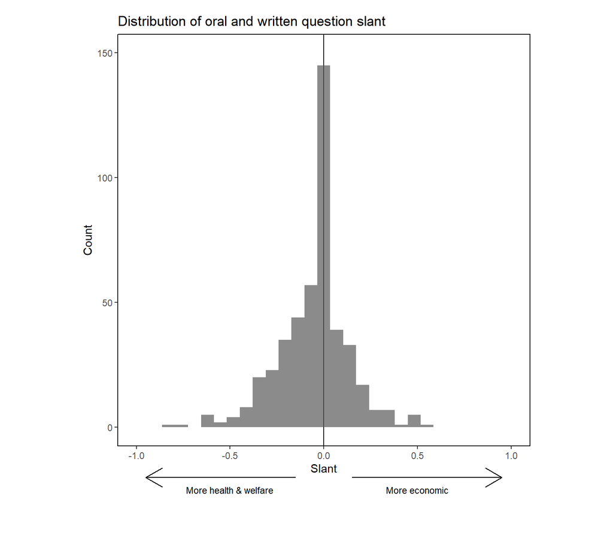

Figure 1: Distribution of slant variable for oral and written questions asked by MPs in 2023. Black line indicates where there is no slant.

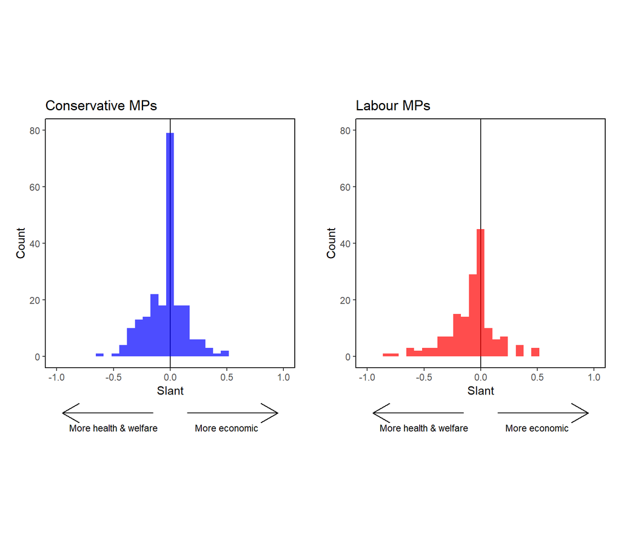

Figure 2: Distribution of slant variable for oral and written questions asked by MPs in 2023 amongst MPs in the two main parties. Black line indicates where there is no slant.

[figure not shown]

Figure 3: Map showing the geographic distribution of question slant. A slant score of -1 indicates all questions were about health and welfare issues, a score of 1 indicates all questions were about economic issues. Constituencies shown as grey are where the MP asked no oral or written questions in 2023.

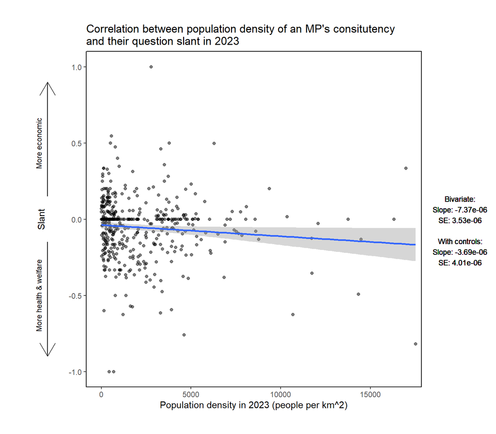

Figure 4: A slant score of -1 indicates all questions were about health and welfare issues, a score of 1 indicates all questions were about economic issues.

Finally, the relationship between health & welfare questions and population could be driven by more welfare recipients living in urban areas. *Figure 5*, however, shows there is no overall relationship – whether controls are added or not - between the number of households receiving universal claimants and focus on health & welfare issues.

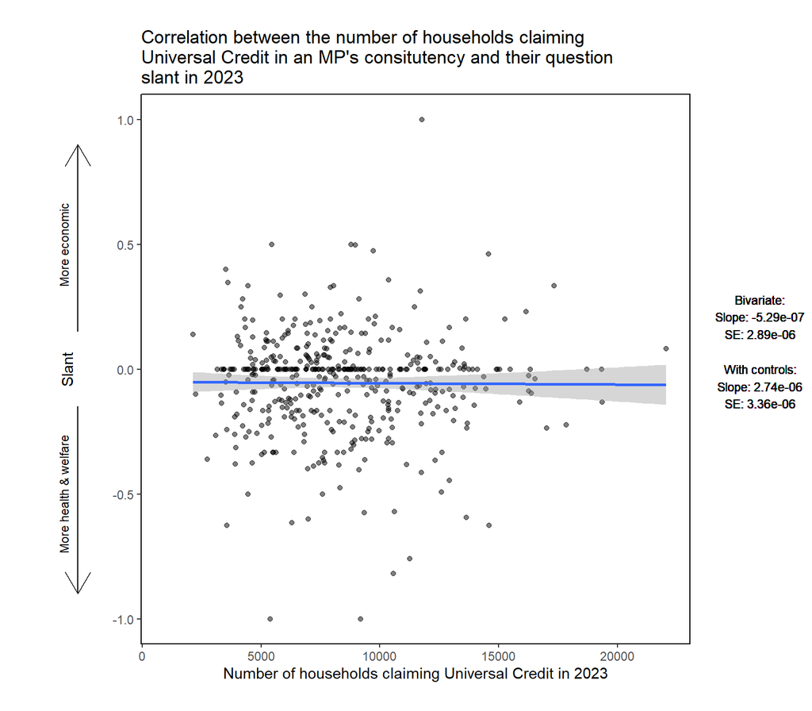

Figure 5: A slant score of -1 indicates all questions were about health and welfare issues, a score of 1 indicates all questions were about economic issues.

Overall, controlling for an MP’s party and marginality, the urbaneness of an MP’s seat does not appear to predict question slant. This suggests that other factors about an MP’s seat, or factors related to the MP themselves – e.g. their party - may be better discriminators of whether they ask economic or health & welfare questions.

# References

Albugh, Quinn, Julie Sevenans and Stuart Soroka. 2013. Lexicoder Topic Dictionaries, June 2013 versions, McGill University, Montreal, Canada.

# Code appendix

```r
knitr::opts_chunk$set(
    echo = FALSE,
    eval = FALSE,
    message = FALSE,
    warning = FALSE,
    error = FALSE,
    fig.width=8, fig.height=7,
    fig.align='center')

# Please note, all data collection chunks are set to eval=FALSE.
# They only need to be run once to populate the local relational database.
# To knit this document, chang eval = FALSE to eval = TRUE.
# Please note, this will take a long time to run because of the scraping code


# Can also be run by sourcing scripts/00_setup.R

# Define function to install or load packages
load_packages <- function(x) {
  y <- x %in% rownames(installed.packages())
  if(any(!y)) install.packages(x[!y])
  invisible(lapply(x, library, character.only=T))
  rm(x, y)
}

# Load required packagess
load_packages(c(
    "tidyverse",
    "here",
    # Database management
    "DBI",
    "RSQLite",
    # APIs and webscraping
    "httr",
    "RSelenium",
    # Text analysis
    "tm",
    "XML",
    # Geospatial plots
    "tmap",
    "sf",
    "ggrepel",
    # Plotting
    "gridExtra"
    ))

replace_null_with_na <- function(x) { # NOTE function adapted from ChatGPT output
  if (is.list(x)) { # Checks for whether the item is a sublist
    lapply(x, replace_null_with_na) # if it is, apply the function for each of the elements within the sublist
  } else { # If it isn't, simply apply the main function
    ifelse(is.null(x) || x == "null", "NA", x)
  }
}


# When flattening the API responses, we replace null values with character "NA" values (using the function above), this function converts them back to NAs that R can recognise:
replace_na_chr <- function(df) { # NOTE function adapted from ChatGPT output
  df <- df %>%
    mutate(across(where(is.character), ~na_if(., "NA")))

  return(df)
}

db_table_check <- function(table){
  rows <- dbGetQuery(db, paste0("SELECT COUNT(1) FROM ", table))
  cols <- dbListFields(db, table)

  result = list(
    table = table,
    n_rows = rows[[1]],
    col_names = cols)
  return(result)
}

# Connect to local relational database
db <- DBI::dbConnect(RSQLite::SQLite(), here("data/parliament_database.sqlite"))


# This code can also be run by sourcing scripts/01_pull-oral-questions.R

# Define function to construct request URL and execute request
GET_qs <- function(endpoint_url, n_skip = 0) {
  url <- paste0(
    endpoint_url,
    "?parameters.skip=",
    n_skip,
    "&parameters.answeringDateStart=2023-01-01&parameters.answeringDateEnd=2023-12-31", # Limit to 2023
    "&parameters.take=100")

  response <-
    httr::GET(url) %>%
    httr::content("parsed") # Use :: because the tm package masks content

  return(response)
}

# Define function to pull all oral questions

pull_all_oral_qs <- function(endpoint_url){

  # Calculate how many questions are in the end point
  n_resp <- httr::GET(paste0(
    endpoint_url,
    "?parameters.answeringDateStart=2023-01-01&parameters.answeringDateEnd=2023-12-31", # Limit to 2023
    "&parameters.take=1")) %>%
    httr::content("parsed")

  n <- n_resp$PagingInfo$GlobalTotal

  # Questions can be pulled in batches of 100,
  # calculate how many times we will have to pull
  n_loops <- ceiling(n / 100)

  print(paste0("LOG | ", Sys.time(), " | Oral question pull starting"))

  for (i in 1:n_loops) {

    n_skip <- (i - 1) * 100 # Skip however many 100s the loop has run

    if (i == 1) { # On first iteration, make new list

      response <- GET_qs(endpoint_url, n_skip)
      response <- response$Response

    } else { # On all other iterations, append to existing list

      response_new <- GET_qs(endpoint_url, n_skip)
      response_new <- response_new$Response
      response <- c(response, response_new) # Merge responses

    }

    print(paste0("LOG | ", Sys.time(), " | ", i, " of ", n_loops, " done.")) # Print progress message
    Sys.sleep(1) # Sleep to avoid hammering the API

  }

  print(paste0("LOG | ", Sys.time(), " | Oral question pull done :)"))
  return(response)
}

## Apply pull oral question function

oral_questions <- pull_all_oral_qs(
  "https://oralquestionsandmotions-api.parliament.uk/oralquestions/list")

# Save output to RDS

saveRDS(oral_questions, "data/oral_questions_2023.RDS")


# This code can also be run by sourcing scripts/02_pull-written-questions.R

# Define function to construct request URL and execute request

GET_qs_written <- function(endpoint_url, n_skip = 0) {
  url <- paste0(
    endpoint_url,
    "?skip=",
    n_skip,
    "&tabledWhenFrom=2023-01-01&tabledWhenTo=2023-12-31", # Limit to 2023
    "&house=Commons", # Limit to HoC
    "&take=100")

  response <-
    httr::GET(url) %>%
    httr::content("parsed") # Use :: because tm masks content

  return(response)
}

# Define function to pull all written questions

pull_all_written_qs <- function(endpoint_url){


  # Calculate how many questions are in the end point
  n_resp <- httr::GET(
    paste0(
      endpoint_url,
      "?tabledWhenFrom=2023-01-01&tabledWhenTo=2023-12-31", # Limit to 2023
      "&house=Commons", # Limit to HoC
      "&take=1")) %>%
    httr::content("parsed")

    n <- n_resp$totalResults

    # Questions can be pulled in batches of 100, calculate how many time we will have to pull
    n_loops <- ceiling(n/100)

    for(i in 1:n_loops){

        n_skip <- (i-1)*100 # Skip however many 100s the loop has run

        if(i==1){ # On first iteration, make new list

            response <- GET_qs_written(endpoint_url, n_skip)
            response <- response$results

        } else { # On all other iterations, append to existing list
            responseNew <- GET_qs_written(endpoint_url, n_skip)
            responseNew <- responseNew$results

            response <- c(response, responseNew) # Merge responses
        }

    print(paste0("LOG | Written questions | ", Sys.time(), " | ", i, " of ", n_loops, " done.")) # Print progress message

    Sys.sleep(0.5) # Sleep to avoid hammering the API
    }

 print(paste0("LOG | Written questions | ", Sys.time(), " | Written question pull done :)"))
 return(response)
```

```r
}


written_questions <- pull_all_written_qs("https://questions-statements-api.parliament.uk/api/writtenquestions/questions")


saveRDS(written_questions, "data/written_questions_2023.RDS")


oral_questions <- readRDS("data/oral_questions_2023.RDS")

# Convert list into dataframe

for (i in seq_along(oral_questions)) {
   # remove sublists, otherwise names do not match
    oral_questions[[i]]$AskingMember <- NULL
    oral_questions[[i]][["AnsweringMinister"]] <- NULL

    oral_questions[[i]] <- replace_null_with_na(oral_questions[[i]])

  if (i == 1){
    oral_question_df <- data.frame(oral_questions[[i]])
  } else {
    oral_question_df2 <- data.frame(oral_questions[[i]])
    oral_question_df <- rbind(oral_question_df, oral_question_df2)
  }
}

rm(oral_question_df2, i)

### Clean dataframes and merge into one table ####

oral_question_df <- oral_question_df %>%
  # Select a subset of variables to keep
  select(
    question_id = Id,
    question_text = QuestionText,
    asking_member = AskingMemberId,
    question_tabled_when = TabledWhen,
    question_answering_when = AnsweringWhen,
    question_answering_body = AnsweringBody,
    question_answering_body_id = AnsweringBodyId,
    answering_member = AnsweringMinisterId) %>%
  # Ensure variables are the correct class
  mutate(
    question_id = as.character(question_id),
    question_text = as.character(question_text),
    asking_member = as.character(asking_member),
    question_tabled_when = as.character(as.Date(question_tabled_when)),
    question_answering_when = as.character(as.Date(question_answering_when)),
    question_answering_body = as.character(question_answering_body),
    question_answering_body_id = as.character(question_answering_body_id),
    answering_member = as.character(answering_member),
    oral_written = "oral") # add written_oral dummy


written_questions <- readRDS("data/written_questions_2023.RDS")

for (i in seq_along(written_questions)) {

  # Remove links sublist by keeping only "value"
  written_questions[[i]] <- written_questions[[i]]$value

  # remove sublists, otherwise names do not match.
  written_questions[[i]]$groupedQuestions <- NULL
  written_questions[[i]]$attachments <- NULL
  written_questions[[i]]$groupedQuestionsDates <- NULL

  # Replace nulls with NAs so lengths of lists are constant
  written_questions[[i]] <- replace_null_with_na(written_questions[[i]])

  if (i == 1){
    written_question_df <- data.frame(written_questions[[i]])
  } else {
    written_question_df2 <- data.frame(written_questions[[i]])
    written_question_df <- rbind(written_question_df, written_question_df2)
  }

  # Print progress message
  print(paste0(i, " of ", length(written_questions)))
}

rm(written_question_df2, i)

written_question_df <- written_question_df %>%
  select(
  # Select a subset of variables to keep
    question_id = id,
    question_text = questionText,
    asking_member = askingMemberId,
    question_tabled_when = dateTabled,
    question_answering_when = dateForAnswer,
    question_answering_body = answeringBodyName,
    question_answering_body_id = answeringBodyId,
    answering_member = answeringMemberId) %>%
  # Ensure variables are the correct class
  mutate(
    question_id = as.character(question_id),
    question_text = as.character(question_text),
    asking_member = as.character(asking_member),
    question_tabled_when = as.character(as.Date(question_tabled_when)),
    question_answering_when = as.character(as.Date(question_answering_when)),
    question_answering_body = as.character(question_answering_body),
    question_answering_body_id = as.character(question_answering_body_id),
    answering_member = as.character(answering_member),
    oral_written = "written") # add written_oral dummy


question_df <- rbind(oral_question_df, written_question_df)

dbWriteTable(db, "questions", question_df, overwrite = TRUE)

rm(oral_question_df, written_question_df, question_df)

# This code can also be run by sourcing scripts/03_pull-members-endpoint.R

pull_members <- function(base_url, df) {

  for (i in seq_along(df$member_id)) {

    # Build request URL
    url <- paste0(
      base_url, "/",
      df$member_id[i],
      "?detailsForDate=",
      df$question_tabled_when[i])

    if (i == 1) { # If 1st iteration, create response,

      response <- httr::GET(url) %>% httr::content("parsed") # Pull request
      response <- response[1] # Extract list with response
      response <- c(
        date = df$question_tabled_when[i], response[[1]]) # Merge with date
      response <- list(response) # Convert to list

    } else { #  else create response2, then merge
      response_new <- httr::GET(url) %>% httr::content("parsed")
      response_new <- response_new[1]
      response_new <- c(
        date = df$question_tabled_when[i], response_new[[1]])
      response_new <- list(response_new)

      response <- c(response, response_new) # Merge responses
    }

    Sys.sleep(1)

    print(paste0("LOG Member Pull | ", Sys.time(), " | ", i, " of ", nrow(df), " done"))
  }
  return(response)
}

# As MP characteristics - e.g. party affiliation - change over time, we need to
# ensure the information we pull is valid for the day of the question.
# The approach I used was to make a request for each unique day-MP pairs.
# This can later be summarised into ranges for which any unique set of MP covariates are valid.

# Query question table to get MP-date pairs

members_asking <- dbGetQuery(db,
  "
  SELECT
    asking_member AS member_id,
    question_tabled_when
  FROM questions
  ")  %>%
  replace_na_chr() # When flattening the API responses, we replaced null values with character "NA" values, this function converts them back to NAs that R can recognise.

ministers_answering <- dbGetQuery(db,
  "
  SELECT
    answering_member AS member_id,
    question_tabled_when
  FROM questions
  ")  %>%
  replace_na_chr()

q_parameters <- rbind(members_asking, ministers_answering)

# Only keep unique MP-date pairs to avoid pulling the same information twice
q_parameters <- unique(q_parameters) %>%
  filter(member_id != 0) # Remove 0s because these indicate no minister has answered
```

```r
# Apply function to pull members
members <- pull_members(
  "https://members-api.parliament.uk/api/Members",
  q_parameters)

saveRDS(members, "data/members_raw.Rds")

members <- readRDS("data/members_raw.Rds")

# Replace "null" values with NA so they are kept in the structure of the list
members <-  lapply(
  members,
  function(x) {lapply(x, replace_null_with_na)})

# Convert to dataframe
for (i in seq_along(members)) {
    if (i == 1) {
      members_df <- members[i] %>%
        unlist() %>%
        t() %>%
        data.frame()
    } else {
      members_df_new <- members[i] %>%
        unlist() %>%
        t() %>%
        data.frame()
      members_df <- rbind(members_df, members_df_new)
    }
}

members_df <- members_df %>%
  select(
    member_date_valid = date,
    member_id = id,
    name_display = nameDisplayAs,
    gender = gender,
    latest_constituency = latestHouseMembership.membershipFromId,
    latest_party_id = latestParty.id
  )

# Some MP characteristics change over time, so we collected unique MP-day queries.
# However, characteristics do not change daily so there is lots of repitition.
# The following code groups MPs by the mutable variables (i.e. unique combinations,
# then summarises the earliest valid, and the latest valid date)
# Before this function there are 4225 observations, and after, only 482.

members_df_grouped <- members_df %>%
  group_by( # Group by all variables apart from date
    member_id,
    name_display,
    gender,
    latest_constituency,
    latest_party_id
  ) %>%
  summarize( # Summarise earliest date this is valid for and latest. This gives us a range of vlaues where this combination is duplicated
    member_date_valid_min = min(member_date_valid),
    member_date_valid_max = max(member_date_valid)
  ) %>%
  mutate(
    member_id = as.character(member_id),
    name_display = as.character(name_display),
    gender = as.character(gender),
    latest_constituency = as.character(latest_constituency),
    latest_party_id = as.character(latest_party_id),
    member_date_valid_min = as.character(member_date_valid_min),
    member_date_valid_max = as.character(member_date_valid_max)
  )

#unique(members_df$member_id) %>% length() # This returns 474, indicating there are changes

dbWriteTable(db, "members", members_df_grouped, overwrite = TRUE)


# This code can also be run by sourcing scripts/04_pull-constituency-endpoints.R

# Query members table
MPs <- dbGetQuery(db,
  "
  SELECT *
  FROM members
  ")  %>%
  replace_na_chr()

#Define a list of unique constituencies we want to pull information for
constituencies <- MPs$latest_constituency %>%
  unique()

# Initialise an empty dataframe
constituencies <-
  data.frame(
    constituency_id = constituencies
  ) %>%
  mutate(

    cons_name = NA,
    cons_start_date = NA,
    cons_end_date = NA,

    last_election_1_electorate = NA,
    last_election_1_turnout = NA,
    last_election_1_majority = NA,
    last_election_1_result = NA,
    last_election_1_winning_party = NA,
    last_election_1_election_ID = NA,
    last_election_1_electionDate = NA,
    last_election_1_isGeneralElection = NA,

    last_election_2_electorate = NA,
    last_election_2_turnout = NA,
    last_election_2_majority = NA,
    last_election_2_result = NA,
    last_election_2_winning_party = NA,
    last_election_2_election_ID = NA,
    last_election_2_electionDate = NA,
    last_election_2_isGeneralElection = NA,

    last_election_3_electorate = NA,
    last_election_3_turnout = NA,
    last_election_3_majority = NA,
    last_election_3_result = NA,
    last_election_3_winning_party = NA,
    last_election_3_election_ID = NA,
    last_election_3_electionDate = NA,
    last_election_3_isGeneralElection = NA,

    last_election_4_electorate = NA,
    last_election_4_turnout = NA,
    last_election_4_majority = NA,
    last_election_4_result = NA,
    last_election_4_winning_party = NA,
    last_election_4_election_ID = NA,
    last_election_4_electionDate = NA,
    last_election_4_isGeneralElection = NA,

    shapefile = NA
    )

### Pull basic details

pull_const_info <- function(cons_id) {
  url <- paste0(
    "https://members-api.parliament.uk/api/Location/Constituency/",
    cons_id)

    basic_info <- httr::GET(url) %>%
    httr::content("parsed")

    return(basic_info)
}

# Write out to the dataframe
for(i in seq_along(constituencies$constituency_id)) {
  response <- pull_const_info(constituencies$constituency_id[i])
  response <- response[[1]]

  constituencies$cons_name[i] <- response$name
  constituencies$cons_start_date[i] <- response$startDate
  constituencies$cons_end_date[i] <- ifelse(is.null(response$endDate), NA, response$endDate)

  Sys.sleep(0.5)
  print(paste0("LOG | Constituency API call - basic | ", Sys.time(), " | ", i, " of ", length(constituencies$constituency_id), " done"))

}

### Pull shape file

get_cons_shapefile <- function(cons_id) {
  url <- paste0(
    "https://members-api.parliament.uk/api/Location/Constituency/",
    cons_id,
    "/Geometry")

  shapefile <- httr::GET(url) %>%
    httr::content("parsed")

  return(shapefile)
}

# Write out to the dataframe

for(i in seq_along(constituencies$constituency_id)) {
  response <- get_cons_shapefile(constituencies$constituency_id[i])
  response <- response[[1]]

  constituencies$shapefile[i] <- response

  Sys.sleep(0.5)
  print(paste0("LOG | Constituency API call - shapefile | ", Sys.time(), " | ", i, " of ", length(constituencies$constituency_id), " done"))
}

### Pull election results

get_cons_election_results <- function(cons_id) {
  url <- paste0(
    "https://members-api.parliament.uk/api/Location/Constituency/",
    cons_id,
    "/ElectionResults")

  results <- httr::GET(url) %>%
    httr::content("parsed")

  return(results)
}

# Write out to the dataframe

for (i in seq_along(constituencies$constituency_id)) {
  response <- get_cons_election_results(constituencies$constituency_id[i])
  response <- response[[1]]

  response <- lapply(response, function(lst) {lapply(lst, replace_null_with_na)})
```

```r
  constituencies$last_election_1_electorate[i] <- response[[1]]$electorate
  constituencies$last_election_1_turnout[i] <- response[[1]]$turnout
  constituencies$last_election_1_majority[i] <- response[[1]]$majority
  constituencies$last_election_1_result[i] <- response[[1]]$result
  # If no winner recorded, skip this and assign NA
  if(length(response[[1]]$winningParty) > 1) { # When there is content in the winning party sublist, the length will be greater than 1
    constituencies$last_election_1_winning_party[i] <- response[[1]]$winningParty$id
  } else {
     constituencies$last_election_1_winning_party[i] <- NA
  }
  constituencies$last_election_1_election_ID[i] = response[[1]]$electionId
  constituencies$last_election_1_electionDate[i] = response[[1]]$electionDate
  constituencies$last_election_1_isGeneralElection[i] = response[[1]]$isGeneralElection

  constituencies$last_election_2_electorate[i] <- response[[2]]$electorate
  constituencies$last_election_2_turnout[i] <- response[[2]]$turnout
  constituencies$last_election_2_majority[i] <- response[[2]]$majority
  constituencies$last_election_2_result[i] <- response[[2]]$result
  # If no winner recorded, skip this and assign NA
  if(length(response[[2]]$winningParty) > 1) {
    constituencies$last_election_2_winning_party[i] <- response[[2]]$winningParty$id
  } else {
     constituencies$last_election_2_winning_party[i] <- NA
  }
  constituencies$last_election_2_election_ID[i] = response[[2]]$electionId
  constituencies$last_election_2_electionDate[i] = response[[2]]$electionDate
  constituencies$last_election_2_isGeneralElection[i] = response[[2]]$isGeneralElection

  constituencies$last_election_3_electorate[i] <- response[[3]]$electorate
  constituencies$last_election_3_turnout[i] <- response[[3]]$turnout
  constituencies$last_election_3_majority[i] <- response[[3]]$majority
  constituencies$last_election_3_result[i] <- response[[3]]$result
  # If no winner recorded, skip this and assign NA
  if(length(response[[3]]$winningParty) > 1) {
    constituencies$last_election_3_winning_party[i] <- response[[3]]$winningParty$id
  } else {
     constituencies$last_election_3_winning_party[i] <- NA
  }
  constituencies$last_election_3_election_ID[i] = response[[3]]$electionId
  constituencies$last_election_3_electionDate[i] = response[[3]]$electionDate
  constituencies$last_election_3_isGeneralElection[i] = response[[3]]$isGeneralElection

  constituencies$last_election_4_electorate[i] <- response[[4]]$electorate
  constituencies$last_election_4_turnout[i] <- response[[4]]$turnout
  constituencies$last_election_4_majority[i] <- response[[4]]$majority
  constituencies$last_election_4_result[i] <- response[[4]]$result
  # If no winner recorded, skip this and assign NA
  if(length(response[[4]]$winningParty) > 1) {
    constituencies$last_election_4_winning_party[i] <- response[[4]]$winningParty$id
  } else {
     constituencies$last_election_4_winning_party[i] <- NA
  }
  constituencies$last_election_4_election_ID[i] = response[[4]]$electionId
  constituencies$last_election_4_electionDate[i] = response[[4]]$electionDate
  constituencies$last_election_4_isGeneralElection[i] = response[[4]]$isGeneralElection

  Sys.sleep(0.5)

  print(paste0("LOG | Constituency API call - elections | ", Sys.time(), " | ", i, " of ", length(constituencies$constituency_id), " done"))
}

saveRDS(constituencies, "data/constituencies_api_raw.Rds")

# This code can also be run by sourcing scripts/04_selinium-scrape-HoC-dashboard.R

# NOTE cons_hoc returns 610 not 472 because it was pulled based on constituencies in all oral questions, not just 2023

# Read in data from the constituency endpoint pull
cons <- readRDS("data/constituencies_api_raw.Rds")

# Make new dataframe
cons <- cons %>%
  select(constituency_id, cons_name) %>%
  unique() %>% # Keep only unqiue constituencies
  mutate( # Initialise variables
    region_nation_hoclib23 = NA,
    population_hoclib23 = NA,
    area_hoclib23 = NA,
    age_0_29_hoclib23 = NA,
    age_30_64_hoclib23 = NA,
    age_65_plus_hoclib23 = NA,
    uc_claimants_hoclib23 = NA,
    median_house_price_hoclib23 = NA
  )

# Check whether constituencies have already been pulled and saved. If they have, filter out these so they are not re-scraped.
# If running for the first time, you will not be able to read in cons_hoc, so the filtering is skipped.
if (file.exists("data/hoc_library_scrape_raw.Rds")) {
  cons_hoc <- readRDS("data/hoc_library_scrape_raw.Rds")
  cons$check_already_pulled <- cons$cons_name %in% cons_hoc$cons_name
  cons <- cons %>% filter(check_already_pulled == FALSE)
}

# Set selinium browser
rD <- rsDriver(browser=c("firefox"), verbose = F, port = netstat::free_port(random = TRUE), chromever = NULL)
driver <- rD$client

# Define a list of css selectors

# The dashboard is contained within an "iframe".
# This allows a different html tree to be embedded within the main html of the webpage meaning any CSS paths do not point to the actual path of the webpage.
# To do this, we need to identify the iframe and use `switchToFrame()` to identify elements on the dashboard.

selector_list <- list()

selector_list$search_dropdown <- "/html/body/div[1]/report-embed/div/div[1]/div/div/div/div/exploration-container/div/div/docking-container/div/div/div/div/exploration-host/div/div/exploration/div/explore-canvas/div/div[2]/div/div[2]/div[2]/visual-container-repeat/visual-container[1]/transform/div/div[3]/div/div/visual-modern/div/div/div[2]/div/i"

selector_list$search_box <- "/html/body/div[7]/div[1]/div/div[1]/input"

selector_list$search_result <- "/html/body/div[7]/div[1]/div/div[2]/div/div[1]/div/div/div[1]/div/span"

selector_list$region_nation <- "/html/body/div[1]/report-embed/div/div[1]/div/div/div/div/exploration-container/div/div/docking-container/div/div/div/div/exploration-host/div/div/exploration/div/explore-canvas/div/div[2]/div/div[2]/div[2]/visual-container-repeat/visual-container[2]/transform/div/div[3]/div/div/visual-modern/div/div/div/div[1]/div/div/div/div/div"
```

```r
selector_list$population <- "/html/body/div[1]/report-embed/div/div[1]/div/div/div/div/exploration-container/div/div/docking-container/div/div/div/div/exploration-host/div/div/exploration/div/explore-canvas/div/div[2]/div/div[2]/div[2]/visual-container-repeat/visual-container[3]/transform/div/div[3]/div/div/visual-modern/div/div/div/p[2]/span"

selector_list$area <- "/html/body/div[1]/report-embed/div/div[1]/div/div/div/div/exploration-container/div/div/docking-container/div/div/div/div/exploration-host/div/div/exploration/div/explore-canvas/div/div[2]/div/div[2]/div[2]/visual-container-repeat/visual-container[5]/transform/div/div[3]/div/div/visual-modern/div/div/div/p[2]/span"

selector_list$age_0_29 <- "/html/body/div[1]/report-embed/div/div[1]/div/div/div/div/exploration-container/div/div/docking-container/div/div/div/div/exploration-host/div/div/exploration/div/explore-canvas/div/div[2]/div/div[2]/div[2]/visual-container-repeat/visual-container[11]/transform/div/div[3]/div/div/visual-modern/div/div/div/div[1]/div/div/div/div/div/div[1]"

selector_list$age_30_64 <- "/html/body/div[1]/report-embed/div/div[1]/div/div/div/div/exploration-container/div/div/docking-container/div/div/div/div/exploration-host/div/div/exploration/div/explore-canvas/div/div[2]/div/div[2]/div[2]/visual-container-repeat/visual-container[13]/transform/div/div[3]/div/div/visual-modern/div/div/div/div[1]/div/div/div/div/div/div[1]"

selector_list$age_65_plus <- "/html/body/div[1]/report-embed/div/div[1]/div/div/div/div/exploration-container/div/div/docking-container/div/div/div/div/exploration-host/div/div/exploration/div/explore-canvas/div/div[2]/div/div[2]/div[2]/visual-container-repeat/visual-container[15]/transform/div/div[3]/div/div/visual-modern/div/div/div/div[1]/div/div/div/div/div/div[1]"

selector_list$uc_claimants <- "/html/body/div[1]/report-embed/div/div[1]/div/div/div/div/exploration-container/div/div/docking-container/div/div/div/div/exploration-host/div/div/exploration/div/explore-canvas/div/div[2]/div/div[2]/div[2]/visual-container-repeat/visual-container[28]/transform/div/div[3]/div/div/visual-modern/div/div/div/div[1]/div/div/div/div/div[1]/div[1]"

selector_list$house_prices <- "/html/body/div[1]/report-embed/div/div[1]/div/div/div/div/exploration-container/div/div/docking-container/div/div/div/div/exploration-host/div/div/exploration/div/explore-canvas/div/div[2]/div/div[2]/div[2]/visual-container-repeat/visual-container[39]/transform/div/div[3]/div/div/visual-modern/div/div/div/div[1]/div/div/div/div/div[2]/div[1]"

constituency_dash_scraper <- function(
  constituency_name,
  wait_base = 1 # Allows user to adjust wait lengths (e.g if running on a slow connection)
                # If you get a 'could not find element' error, try adjusting the wait time as the dashboard takes a while to load
  ){
  # Find dropdown box and click on it
  search_dropdown <- driver$findElement(using = "xpath", value = selector_list$search_dropdown)
  search_dropdown$clickElement()

  # Find search box and type constituency name
  Sys.sleep(wait_base * 2)
  search_box <- driver$findElement(using = "xpath", value = selector_list$search_box)
  #search_box$clickElement() # Do not strictly need this, but if not working try uncommenting
  search_box$clearElement()
  search_box$sendKeysToElement(list(constituency_name))

  Sys.sleep(wait_base * 4) # This requires a long time to load.
  # Click on the first result to load data
  first_result <- driver$findElement(using = "xpath", value = selector_list$search_result)
  first_result$clickElement()

  Sys.sleep(wait_base * 4) # Wait for data to load

  # EXTRACT TEXT FROM ELEMENTS

  # Set defaults as NA
  region_nation_text <- NA
  population_text <- NA
  area_text <- NA
  age_0_29_text <- NA
  age_30_64_text <- NA
  age_65_plus_text <- NA
  uc_claimants_text <- NA
  house_prices_text <- NA

  # Region or nation
  tryCatch({ # Prevent loop from closing if no data available
  suppressMessages({
    region_nation <- driver$findElement(using = "xpath", value = selector_list$region_nation)
    region_nation_text <- region_nation$getElementText()[[1]]
    })
  }, error = function(e) {
    # Print error message, no need to assign NA as we have set NA as default
    print(paste0("Log: NA assigned for REGION/NATION at iteration ", i))
  })

  # Population
  tryCatch({
  suppressMessages({
    population <- driver$findElement(using = "xpath", value = selector_list$population)
    population_text <- population$getElementText()[[1]]
    })
  }, error = function(e) {
    print(paste0("Log: NA assigned for POPULATION at iteration ", i))
  })

  # Area in sq km
  tryCatch({
  suppressMessages({
    area <- driver$findElement(using = "xpath", value = selector_list$area)
    area_text <- area$getElementText()[[1]]
    })
  }, error = function(e) {
    print(paste0("Log: NA assigned for AREA at iteration ", i))
  })

  # Age composition
  tryCatch({
  suppressMessages({
    age_0_29 <- driver$findElement(using = "xpath", value = selector_list$age_0_29)
    age_0_29_text <- age_0_29$getElementText()[[1]]
    })
  }, error = function(e) {
    print(paste0("Log: NA assigned for AGE 0-29 PLUS at iteration ", i))
  })

  tryCatch({
  suppressMessages({
    age_30_64 <- driver$findElement(using = "xpath", value = selector_list$age_30_64)
    age_30_64_text <- age_30_64$getElementText()[[1]]
    })
  }, error = function(e) {
    print(paste0("Log: NA assigned for AGE 30-64 PLUS at iteration ", i))
  })

  tryCatch({
  suppressMessages({
    age_65_plus <- driver$findElement(using = "xpath", value = selector_list$age_65_plus)
    age_65_plus_text <- age_65_plus$getElementText()[[1]]
    })
  }, error = function(e) {
    print(paste0("Log: NA assigned for AGE 64 PLUS at iteration ", i))
  })

  # Universal credit claimants
  tryCatch({
  suppressMessages({
    uc_claimants <- driver$findElement(using = "xpath", value = selector_list$uc_claimants)
    uc_claimants_text <- uc_claimants$getElementText()[[1]]
    })
  }, error = function(e) {
    print(paste0("Log: NA assigned for UC CLAIMANTS at iteration ", i))
  })
```

```r
  # House price
  tryCatch({
    suppressMessages({
      house_prices <- driver$findElement(using = "xpath", value = selector_list$house_prices)
      house_prices_text <- house_prices$getElementText()[[1]]
    })
  }, error = function(e) {
    print(paste0("Log: NA assigned for HOUSE PRICE at iteration ", i))
  })

 # Merge results into a list
  results = list(
    region_nation_text,
    population_text, area_text,
    age_0_29_text, age_30_64_text, age_65_plus_text,
    uc_claimants_text, house_prices_text)

  return(results)

}

# Run the scraper

# Navigate to home page outside of the loop to avoid reloading each time
driver$navigate("https://commonslibrary.parliament.uk/constituency-dashboard/")

Sys.sleep(1)

# The dashboard exists within a sub-page. Unless we "switch" to this subframe, the css paths will be broken
# Identify and switch to sub-page
iframe <- driver$findElement(using = "xpath", value = "//iframe[@title='Constituency dashboard']")
driver$switchToFrame(iframe)
Sys.sleep(4)

# Set the number to start from in case loop is interuppted but we have cached results
start_from = 1

for (i in start_from:length(cons$constituency_id)) {

  results <- constituency_dash_scraper(cons$cons_name[i], wait_base = 1)

    cons$region_nation_hoclib23[i] <- results[[1]]

    cons$population_hoclib23[i] <- results[[2]]

    cons$area_hoclib23[i] <- results[[3]]

    cons$age_0_29_hoclib23[i] <- results[[4]]
    cons$age_30_64_hoclib23[i] <- results[[5]]
    cons$age_65_plus_hoclib23[i] <- results[[6]]

    cons$uc_claimants_hoclib23[i] <- results[[7]]
    cons$median_house_price_hoclib23[i] <- results[[8]]

 # Cache results collected so far
  if(i == start_from){
    saveRDS(cons, paste0("data/cache_cons_at", i, ".Rds"))
  } else {
     saveRDS(cons, paste0("data/cache_cons_at", i, ".Rds"))
     file.remove(paste0("data/cache_cons_at", i-1, ".Rds")) # delete last cached object
  }

  Sys.sleep(1)

  print(paste0(i, " of ", nrow(cons), " done."))

}

# Kill driver and java processes
driver$close()
rD$server$stop()
system("taskkill /im java.exe /f", intern=FALSE, ignore.stdout=FALSE)

if (file.exists("data/hoc_library_scrape_raw.Rds")) {
  cons$check_already_pulled <- NULL
  saveRDS(cons, "data/hoc_library_scrape_raw_extra.Rds")

  cons_hoc <- readRDS("data/hoc_library_scrape_raw.Rds")
  cons <- rbind(cons_hoc, cons)

  saveRDS(cons, "data/hoc_library_scrape_raw.Rds")

} else {
  # Save output
  saveRDS(cons, "data/hoc_library_scrape_raw.Rds")
}


# Clean dashboard data

cons_hoc <- readRDS("data/hoc_library_scrape_raw.Rds")

# Change population to a number
cons_hoc$population_hoclib23 <- cons_hoc$population_hoclib23 %>%
  str_remove_all(",") %>%
  as.numeric()

# Change area to a number

cons_hoc$area_hoclib23 <- cons_hoc$area_hoclib23 %>%
  str_extract(".*(?=\\s*sq\\.\\s*km)") %>%
  str_remove_all(",") %>%
  as.numeric()

# Change age variables to numbers

cons_hoc$age_0_29_hoclib23 <- cons_hoc$age_0_29_hoclib23 %>%
  str_remove_all("%") %>%
  as.numeric()
cons_hoc$age_0_29_hoclib23 <- cons_hoc$age_0_29_hoclib23/100 # Convert to proportion

cons_hoc$age_30_64_hoclib23 <- cons_hoc$age_30_64_hoclib23 %>%
  str_remove_all("%") %>%
  as.numeric()
cons_hoc$age_30_64_hoclib23 <- cons_hoc$age_30_64_hoclib23/100 # Convert to proportion

cons_hoc$age_65_plus_hoclib23 <- cons_hoc$age_65_plus_hoclib23 %>%
  str_remove_all("%") %>%
  as.numeric()
cons_hoc$age_65_plus_hoclib23 <- cons_hoc$age_65_plus_hoclib23/100 # Convert to proportion

# Change universal credit variable to numbers

cons_hoc$uc_claimants_hoclib23 <- cons_hoc$uc_claimants_hoclib23 %>%
  str_remove_all(",") %>%
  as.numeric()

# Change house price variable to numbers

cons_hoc$median_house_price_hoclib23 <- cons_hoc$median_house_price_hoclib23 %>%
  str_remove_all(",|£") %>%
  as.numeric()

# Merge API and dashboard data

cons_api <- readRDS("data/constituencies_api_raw.Rds")

cons_hoc <- cons_hoc %>%
  select(-cons_name)

cons <- left_join(cons_api, cons_hoc, by = "constituency_id")

# Write out to database

dbWriteTable(db, "constituencies", cons, overwrite = TRUE)


# Pull party information to get party names and abbreviations.
# We use this when matching an MPs current party with previous election results.
# Party colours could also be used to colour plots with accruate colours.

response <- httr::GET("https://members-api.parliament.uk/api/Parties/GetActive/1") %>%
  httr::content("parsed")

parties <- response$items
parties <- replace_null_with_na(parties)

for (i in 1:length(parties)) {
  if (i == 1) {
    parties_df <- data.frame(
      party_id = c(parties[[i]]$value$id),
      party_name = c(parties[[i]]$value$name),
      party_abbreviation = c(parties[[i]]$value$abbreviation),
      party_colour = c(parties[[i]]$value$backgroundColour)
    )
  } else {
    parties_df2 <- data.frame(
      party_id = c(parties[[i]]$value$id),
      party_name = c(parties[[i]]$value$name),
      party_abbreviation = c(parties[[i]]$value$abbreviation),
      party_colour = c(parties[[i]]$value$backgroundColour)
    )

    parties_df <- rbind(parties_df, parties_df2)
  }
}

parties_df <- parties_df %>%
  mutate(
    party_id = as.character(party_id),
    party_name = as.character(party_name),
    party_abbreviation = as.character(party_abbreviation),
    party_colour = as.character(party_colour))

dbWriteTable(db, "parties", parties_df, overwrite = TRUE)


question_text <- dbGetQuery(db,
  "
  SELECT question_id, question_text
  FROM questions
  "
)  %>%
  replace_na_chr()

# Measure

# Initalise variables as NA
question_text$is_econ <- NA
question_text$is_health_welf <- NA

# clean question text

question_text$question_text <- question_text$question_text %>%
    tolower() %>% # Convert to lower case
    tm::removePunctuation() # remove punctuation

# Define dictionaries



# Download Lexicon Policy Topic Dictionaries # NOTE Citation: Albugh, Quinn, Julie Sevenans and Stuart Soroka. 2013. Lexicoder Topic Dictionaries, June 2013 versions, McGill University, Montreal, Canada.
```

```r
if (!file.exists("data/lexicoder_dictionaries/LTDjun2013/policy_agendas_english.lcd")) { # Check whether the file has already been downloaded

  dir.create("data/lexicoder_dictionaries")
  download.file(
    "https://www.snsoroka.com/s/LTDjun2013.zip",
    "data/lexicoder_dictionaries/policy_topics.zip")

  unzip(
    "data/lexicoder_dictionaries/policy_topics.zip",
    exdir = "data/lexicoder_dictionaries", overwrite = TRUE)
}

# These files are stored in a propeitrary file format .lcd. However, they are actually XML files.
# Therefore, we can parse them using R's XML package if we read the file in as a raw string
# then parse it.
# After parsing we can conver the XML file into a list of dictionaries.

# NOTE ChatGPT used to write code that parses XML

parsed_string <- readLines("data/lexicoder_dictionaries/LTDjun2013/policy_agendas_english.lcd") %>%
  paste(collapse = "\n") %>%
  xmlTreeParse(useInternalNodes = TRUE)

extract_pnodes <- function(cnode) {
  sapply(xpathApply(cnode, "./pnode"), function(pnode) {
    xmlAttrs(pnode)[["name"]]
  })
}

# Extract cnodes and their corresponding pnodes
dictionaries_output <- xpathApply(parsed_string, "//cnode", function(cnode) {
  cnode_name <- xmlAttrs(cnode)[["name"]]
  pnodes <- extract_pnodes(cnode)
  return(list(cnode_name = cnode_name, pnodes = pnodes))
})

# Convert to a single list
dictionaries <- list()

for (item in dictionaries_output) {
  cnode_name <- item$cnode_name
  pnodes <- item$pnodes
  dictionaries[[cnode_name]] <- pnodes
}

rm(cnode_name, dictionaries_output, item, parsed_string, pnodes, raw_string)

# Select relevant subdictionaries and make terms into a single list

econ_dict <- c( # Select relevant dictionaries.
  dictionaries$macroeconomics, # Contains 84 terms
  dictionaries$finance, # Contains 54 terms
  dictionaries$foreign_trade # Contains 29 terms
  )

health_welf_dict <- c( # Select relevant dictionaries
  dictionaries$healthcare, # Contains 128 terms
  dictionaries$social_welfare # Contains 23 terms
)

# Convert to regex string and convert to lower for matching
econ_dict <- econ_dict %>%
  paste(collapse="|") %>%
  tolower()

health_welf_dict <- health_welf_dict %>%
  paste(collapse="|") %>%
  tolower()

# Use str_detect to detect any occurances of the strings in the dictionary

question_text <- question_text %>%
  mutate(
    is_econ = NA,
    is_health_welf = NA
  ) %>%
  mutate(
    is_econ =
      ifelse(
        str_detect(question_text, econ_dict), 1, 0),
    is_health_welf =
      ifelse(
        str_detect(question_text, health_welf_dict), 1, 0)
  )
dbWriteTable(db, "question_topics", question_text, overwrite = TRUE)

dbListTables(db)
db_table_check("questions")
db_table_check("members")
db_table_check("constituencies")
db_table_check("parties")
db_table_check("question_topics")

# Query data base to construct analysis data
# Once the database has been populated once, all analysis code can be run from here.
# This is where the Rmarkdown file knits from

analysis_df <- dbGetQuery(
  db,
  "
  SELECT

    members.name_display AS MP,
    parties.party_abbreviation AS party_abbreviation,
    parties.party_name AS party,
    parties.party_colour AS party_col,

    SUM(question_topics.is_econ)/COUNT(*) AS econ_prop,
    SUM(question_topics.is_health_welf)/COUNT(*) AS health_welf_prop,

    constituencies.uc_claimants_hoclib23 AS uc_claimants,
    constituencies.median_house_price_hoclib23 AS median_house_price,

    constituencies.population_hoclib23 / constituencies.area_hoclib23 AS density,

    constituencies.age_0_29_hoclib23 AS age_29,
    constituencies.age_30_64_hoclib23 AS age_30_64,
    constituencies.age_65_plus_hoclib23 AS age_65,

    /* Majority */
    constituencies.last_election_1_majority,
    constituencies.last_election_2_majority,
    constituencies.last_election_3_majority,
    constituencies.last_election_4_majority,

    constituencies.last_election_1_electorate,
    constituencies.last_election_2_electorate,
    constituencies.last_election_3_electorate,
    constituencies.last_election_4_electorate,

    /* results */
    constituencies.last_election_1_result,
    constituencies.last_election_2_result,
    constituencies.last_election_3_result,
    constituencies.last_election_4_result

  FROM questions

  JOIN question_topics ON questions.question_id = question_topics.question_id

  /* select row where date of question comes between the dates valid range */
  LEFT JOIN members ON questions.asking_member = members.member_id
    /* this has to be joined before anything */
    /* from members to avoid dropping rows */
    AND REPLACE(questions.question_tabled_when, '-', '')
      BETWEEN REPLACE(members.member_date_valid_min, '-', '') /* no date class in SQLite, so convert to string*/
        AND REPLACE(members.member_date_valid_max, '-', '')

  LEFT JOIN constituencies ON members.latest_constituency = constituencies.constituency_id
  LEFT JOIN parties ON parties.party_id = members.latest_party_id

  GROUP BY members.member_id
  "
  )  %>%
  replace_na_chr()

# Convert majority variables into +/- depending on whether current MP won or lost
analysis_df <- analysis_df %>%
  mutate(
    last_election_1_majority =
      ifelse(str_detect(last_election_1_result, party_abbreviation),
        last_election_1_majority,
        last_election_1_majority * -1),
    last_election_2_majority =
      ifelse(str_detect(last_election_2_result, party_abbreviation),
        last_election_2_majority,
        last_election_2_majority * -1),
    last_election_3_majority =
      ifelse(str_detect(last_election_3_result, party_abbreviation),
        last_election_3_majority,
        last_election_3_majority * -1),
    last_election_4_majority =
      ifelse(str_detect(last_election_4_result, party_abbreviation),
        last_election_4_majority,
        last_election_4_majority * -1)
  ) %>%
  select(-c(last_election_1_result, last_election_2_result, last_election_3_result, last_election_4_result))

# Calculate marginality
analysis_df <- analysis_df %>%
  mutate(
    marginality_1 = (last_election_1_majority / last_election_1_electorate),
    marginality_2 = (last_election_2_majority / last_election_2_electorate),
    marginality_3 = (last_election_3_majority / last_election_3_electorate),
    marginality_4 = (last_election_4_majority / last_election_4_electorate)
  ) %>%
  select(-c(last_election_1_majority, last_election_2_majority, last_election_3_majority, last_election_4_majority, last_election_1_electorate, last_election_2_electorate,last_election_3_electorate,last_election_4_electorate))
```

```r
# Calculate mean marginality
analysis_df <- analysis_df %>%
  mutate(
    mean_marginality = rowMeans(select(., starts_with("marginality_")))
  ) %>%
  select(-c(marginality_1, marginality_2, marginality_3, marginality_4))

# Calculate slant variable

analysis_df <- analysis_df %>%
  mutate(econ_slant = econ_prop - health_welf_prop)

hist <- analysis_df %>%
  ggplot() +
  geom_vline(xintercept = 0)+
  geom_histogram(aes(x=econ_slant), alpha = 0.7) +
  xlim(-1,1)+
  labs(
    title = "Distribution of oral and written question slant",
    x = "Slant", y = "Count") +
  theme(
    aspect.ratio = 1,
    panel.background = element_rect(fill = "white", color = "black"),
    panel.grid = element_blank())


# Add axis labels # NOTE: based on https://stackoverflow.com/questions/12409960/ggplot2-annotate-outside-of-plot and https://stackoverflow.com/questions/10836843/ggplot2-plot-area-margins

hist +
  ggplot2::annotate("segment", y =  -20 , yend = -20, x = -0.15, xend = -0.95, arrow = arrow()) +
  ggplot2::annotate("segment", y =  -20 , yend =  -20, x = 0.15, xend = 0.95, arrow = arrow()) +
  ggplot2::annotate("text", y = -25, x = -0.5, label = "More health & welfare", size = 3) +
  ggplot2::annotate("text", y = -25, x = 0.5, label = "More economic", size = 3) +
  coord_cartesian(xlim = c(-1,1),  ylim=c(0, 150), clip="off") +
  theme(plot.margin = unit(c(1,1,4,1), "lines"))


hist_con <- analysis_df %>%
  filter(party_abbreviation == "Con")%>%
  ggplot() +
  geom_vline(xintercept = 0)+
  geom_histogram(aes(x=econ_slant), alpha = 0.7, fill = "#0000ff") +
  xlim(-1,1)+
  labs(
    title = "Conservative MPs",
    x = "Slant", y = "Count") +
  theme(
    aspect.ratio = 1,
    panel.background = element_rect(fill = "white", color = "black"),
    panel.grid = element_blank()) +
  ggplot2::annotate("segment", y =  -20 , yend = -20, x = -0.15, xend = -0.95, arrow = arrow()) +
  ggplot2::annotate("segment", y =  -20 , yend =  -20, x = 0.15, xend = 0.95, arrow = arrow()) +
  ggplot2::annotate("text", y = -25, x = -0.5, label = "More health & welfare", size = 3) +
  ggplot2::annotate("text", y = -25, x = 0.5, label = "More economic", size = 3) +
  coord_cartesian(xlim = c(-1,1),  ylim=c(0, 80), clip="off") +
  theme(plot.margin = unit(c(1,1,4,1), "lines"))


hist_lab <- analysis_df %>%
  filter(party_abbreviation == "Lab")%>%
  ggplot() +
  geom_vline(xintercept = 0)+
  geom_histogram(aes(x=econ_slant), alpha = 0.7, fill = "#ff0000") +
  xlim(-1,1)+
  labs(
    title = "Labour MPs",
    x = "Slant", y = "Count") +
  theme(
    aspect.ratio = 1,
    panel.background = element_rect(fill = "white", color = "black"),
    panel.grid = element_blank()) +
  ggplot2::annotate("segment", y =  -20 , yend = -20, x = -0.15, xend = -0.95, arrow = arrow()) +
  ggplot2::annotate("segment", y =  -20 , yend =  -20, x = 0.15, xend = 0.95, arrow = arrow()) +
  ggplot2::annotate("text", y = -25, x = -0.5, label = "More health & welfare", size = 3) +
  ggplot2::annotate("text", y = -25, x = 0.5, label = "More economic", size = 3) +
  coord_cartesian(xlim = c(-1,1),  ylim=c(0, 80), clip="off") +
  theme(plot.margin = unit(c(1,1,4,1), "lines"))

grid.arrange(hist_con, hist_lab, nrow=1)


geog_data <- dbGetQuery(db,
  "
  SELECT
    constituencies.cons_name AS constituency,

    SUM(question_topics.is_econ)/COUNT(*) AS econ_prop,
    SUM(question_topics.is_health_welf)/COUNT(*) AS health_welf_prop,

    constituencies.shapefile AS con_shapefile

  FROM questions

  LEFT JOIN members ON questions.asking_member = members.member_id
    /* this has to be joined before anything */
    /* from members to avoid dropping rows */
    /* select row where date of question comes between the dates valid range */

    AND REPLACE(questions.question_tabled_when, '-', '')
    /* no date class in SQLite, so convert to string*/

      BETWEEN REPLACE(members.member_date_valid_min, '-', '')
        AND REPLACE(members.member_date_valid_max, '-', '')

  LEFT JOIN constituencies ON members.latest_constituency = constituencies.constituency_id

  LEFT JOIN question_topics ON questions.question_id = question_topics.question_id

  GROUP BY constituencies.cons_name
  "
  )  %>%
  replace_na_chr() %>%
  filter(!is.na(con_shapefile)) # Drop constituencies without shapefiles

geog_data <- geog_data %>%
  mutate(econ_slant = econ_prop - health_welf_prop)

# Add all constituencies as base map

# To plot the base map, we want all constituencies, not just ones where questions have been asked.
# We can get this from OSMaps
# For reproducibility, the following code downloads and processes the data programmatically
# To download manually, use https://osdatahub.os.uk/downloads/open/BoundaryLine

if (!file.exists("data/whole_UK_shapefile/Data/GB/westminster_const_region.shp")) {

options(timeout=600) # Takes some time to download so we need to increase the "timeout" setting

dir.create("data/whole_UK_shapefile")
httr::GET("https://api.os.uk/downloads/v1/products/BoundaryLine/downloads?area=GB&format=ESRI%C2%AE+Shapefile&redirect", write_disk("data/whole_UK_shapefile/OS_zip.zip", overwrite = TRUE))

options(timeout=60) # Reset timeout

# unzip # FIXME not working
unzip(
  "data/whole_UK_shapefile/OS_zip.zip",
  files = c(
    "Data/GB/westminster_const_region.dbf",
    "Data/GB/westminster_const_region.prj",
    "Data/GB/westminster_const_region.shp",
    "Data/GB/westminster_const_region.shx"),
  exdir = "data/whole_UK_shapefile",
  overwrite = TRUE)
}

basemap_sf <-
  st_read(
    dsn = "data/whole_UK_shapefile/Data/GB/westminster_const_region.shp")

# Make shape files for constituencies in the database

# NOTE: approach to converting from GeoJSON from ChatGPT
temp_geojson <- tempfile(fileext = ".geojson") # Create a temporary file
writeLines(geog_data$con_shapefile, con = temp_geojson) # Write out to temporary file
geog_sf <- st_read(dsn = temp_geojson) # Read the GeoJSON file into an sf object
unlink(temp_geojson) # Delete temporary file

geog_data <- cbind(geog_data, geog_sf)
geog_data <- st_as_sf(geog_data) # Convert to SF
```

```r
map <-
  tm_shape(basemap_sf) +
  tm_sf(col = "lightgrey") +
  tm_shape(geog_data) +
  tm_polygons(
    col = "econ_slant",
    style = "cont",
    midpoint = 0,
    title = "Question topic slant",
    palette = "RdBu"
  ) +
  tm_legend(
    legend.position = c("right", "center"),
    legend.title.size = 4,
    legend.text.size = 3
  ) +
  tm_layout(
    main.title = "Distribution of question topic slant across UK Constituencies",
    main.title.size = 4,
    main.title.position = "left"
  )

map

lm_density <- summary(lm(econ_slant ~ density + party + mean_marginality, data = analysis_df))
lm_density_biv <- summary(lm(econ_slant ~ density, data = analysis_df))

slope_density <- lm_density$coefficients[[2,1]]
se_density <- lm_density$coefficients[[2,2]]

slope_density_biv <- lm_density_biv$coefficients[[2,1]]
se_density_biv <- lm_density_biv$coefficients[[2,2]]

plot_density <- analysis_df %>%
  ggplot(aes(x=density, y = econ_slant)) +
  geom_point(alpha = 0.5) +
  geom_smooth(method = "lm") +
  labs(
    title = "Correlation between population density of an MP's consitutency\nand their question slant in 2023",
    x = "Population density in 2023 (people per km^2)",
    y = "Slant\n\n") +
  ylim(-1,1) +
  theme(
    panel.background = element_rect(fill = "white", color = "black"),
    aspect.ratio = 1,
    panel.grid = element_blank()
  )

plot_density +
  geom_text(
    aes(x=20000, y= slope_density*20000),
    label = paste0(
      "Bivariate:",
      "\nSlope: ", signif(slope_density_biv, digits = 3),
      "\nSE: ", signif(se_density_biv, digits = 3),
      "\n\nWith controls:",
      "\nSlope: ", signif(slope_density, digits = 3),
      "\nSE: ", signif(se_density, digits = 3)
    ), size = 3)+
  ggplot2::annotate("segment", x =  -3000 , xend = -3000, y = -0.15, yend = -0.9, arrow = arrow()) +
  ggplot2::annotate("segment", x =  -3000 , xend =  -3000, y = 0.15, yend = 0.9, arrow = arrow()) +
  ggplot2::annotate("text", x = -3500, y = -0.5, label = "More health & welfare", size = 3, angle = 90) +
   ggplot2::annotate("text", x = -3500, y = 0.5, label = "More economic", size = 3, angle = 90) +

  coord_cartesian(xlim = c(0,17000),  ylim=c(-1, 1), clip="off") +
  theme(plot.margin = unit(c(1,6,1,3), "lines"))

# Run linear model
lm_uc <- summary(lm(econ_slant ~ uc_claimants + party + mean_marginality, data = analysis_df))
lm_uc_biv <- summary(lm(econ_slant ~ uc_claimants, data = analysis_df))
# Save slope coefficients and SEs for plotting

slope_uc <- lm_uc$coefficients[[2,1]]
se_uc <- lm_uc$coefficients[[2,2]]

slope_uc_biv <- lm_uc_biv$coefficients[[2,1]]
se_uc_biv <- lm_uc_biv$coefficients[[2,2]]

# Make plots

plot_uc <- analysis_df %>%
  ggplot(aes(x=uc_claimants, y = econ_slant)) +
  geom_point(alpha = 0.5) +
  geom_smooth(method = "lm") +
  labs(
    title = "Correlation between the number of households claiming\nUniversal Credit in an MP's consitutency and their question\nslant in 2023",
    x = "Number of households claiming Universal Credit in 2023",
    y = "Slant\n\n") +
  ylim(-1,1) +
  theme(
    aspect.ratio = 1,
    panel.background = element_rect(fill = "white", color = "black"),
    panel.grid = element_blank())


plot_uc +
  geom_text(
    aes(x=26000, y= slope_uc*26000),
    label = paste0(
      "Bivariate:",
      "\nSlope: ", signif(slope_uc_biv, digits = 3),
      "\nSE: ", signif(se_uc_biv, digits = 3),
      "\n\nWith controls:",
      "\nSlope: ", signif(slope_uc, digits = 3),
      "\nSE: ", signif(se_uc, digits = 3)
    ), size = 3)+
  ggplot2::annotate("segment", x =  -2700 , xend = -2700, y = -0.15, yend = -0.9, arrow = arrow()) +
  ggplot2::annotate("segment", x =  -2700 , xend =  -2700, y = 0.15, yend = 0.9, arrow = arrow()) +
  ggplot2::annotate("text", x = -3300, y = -0.5, label = "More health & welfare", size = 3, angle = 90) +
  ggplot2::annotate("text", x = -3300, y = 0.5, label = "More economic", size = 3, angle = 90) +

  coord_cartesian(xlim = c(1000,22000),  ylim=c(-1, 1), clip="off") +
  theme(plot.margin = unit(c(1,6,1,3), "lines"))

# Disconnect from local database
DBI::dbDisconnect(db)
```